# Loading data from the internet

**Nathan Brouwer, Phd** brouwern@gmail.com https://github.com/brouwern @lobrowR

# Introduction

Its possible to download data directly from the internet, including

- Spreadsheets directly posted online as .csv or .txt
- Spreadsheets contained within a GitHub repository, including a package
- Google Sheets
- and many other formats

In this short execise we’ll download some data that is stored as a raw .csv file within the inner workings of the widlifeR package.

### Functions & Arguements

- RCurl::getURL()
- scatter.smooth

### Packages

- RCurl install.packages()

## [ ] Downloading a .csv file using getURL()

The package RCurl provides functions for accessing online material. First we need the package

```r
install.packages(RCurl, dependencies = TRUE) # [ ]
```

As always, once we install a package we need to **really** install it with library(). (You might see some red text as RCurl loads up some of its **dependencies**)

```r
library(RCurl) # [ ]
```

We then use the getURL() to prep the info we need for downloading that .csv we want.

The file we want is “eaglesWV.csv”. It is located at this rather long URL: https://raw.githubusercontent.com/brouwern/wildlifeR/master/inst/extdata/eaglesWV.csv

First, we’ll use the “<-” assignment operator to store the shortened URL in an R object. Be sure to put the URL in quotes.

```r
eaglesWV.url <- "https://raw.githubusercontent.com/brouwern/wildlifeR/master/inst/extdata/eaglesWV.csv" # [ ]
```

Next we’ll use the getURL() function to set thigns up, storing the info in a new object “eaglesWV.url_2” (note the “_2" on the end)

```r
eaglesWV.url_2 <- getURL(eaglesWV.url)
```

```r
eaglesWV_2 <- read.csv(text = eaglesWV.url_2)
```

We can preview the downloaded dataset using summary() or any other command we want

```r
summary(eaglesWV_2)
```

```
##       year            WV
##  Min.   :1980   Min.   : 0.000
##  1st Qu.:1994   1st Qu.: 4.000
##  Median :2001   Median : 5.000
##  Mean   :2001   Mean   : 6.882
##  3rd Qu.:2008   3rd Qu.:10.000
##  Max.   :2015   Max.   :19.000
##                 NA's   :12
```

**OPTIONAL:** Plotting West Virginia Eagle Data Thanksfully, eagles having been increasing exponentially in West Virginia since the 1980s.

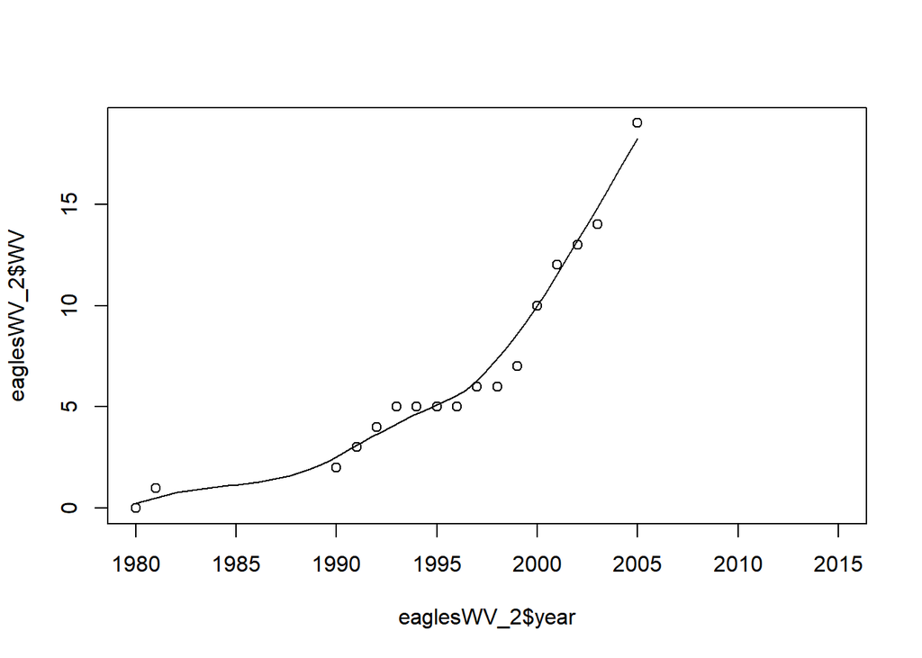

```r
scatter.smooth(y = eaglesWV_2$WV,x = eaglesWV_2$year)
```